# Homeworks

# Homework 6 (2020-11-03)

## Exercise 7.1

### Problem

Compute a jackknife estimate of the bias and the standard error of the correlation statistic in Example 7.2.

### Solution

```r
set.seed(3333)
library(bootstrap)
law <- as.matrix(law)
corr <- cor(law[,1],law[,2])
n <- nrow(law)
jackknife_store <- rep(0,n)
for (i in 1:n) {
  jacksample <- law[-i,]
  jackknife_store[i] <- cor(jacksample[,1],jacksample[,2])
}
jackknife_bias <- (n-1)*(mean(jackknife_store)-corr)
jackknife_se <- (n-1)*sd(jackknife_store)/sqrt(n)
c(jackknife_bias, jackknife_se)
```

```
## [1] -0.006473623  0.142518619
```

```r
# Bias=-0.006473623, SE=0.1425186
```

## Exercise 7.5

### Problem

Refer to Exercise 7.4. Compute 95% bootstrap confidence intervals for the mean time between failures $1/\lambda$ by the standard normal, basic, percentile, and BCa methods. Compare the intervals and explain why they may differ.

### Solution

```r
set.seed(3333)
library(boot)
aircondit <- as.matrix(aircondit)
boot.mean <- function(x,i) mean(x[i])
boot.obj <- boot(aircondit, statistic=boot.mean, R=2000)
print(boot.ci(boot.obj, type = c("norm","basic","perc","bca")))
```

```
## BOOTSTRAP CONFIDENCE INTERVAL CALCULATIONS
## Based on 2000 bootstrap replicates
##
## CALL :
## boot.ci(boot.out = boot.obj, type = c("norm", "basic", "perc",
##     "bca"))
##
## Intervals :
## Level      Normal              Basic
## 95%   ( 34.7, 180.4 )   ( 23.0, 167.5 )
##
## Level     Percentile            BCa
## 95%   ( 48.7, 193.2 )   ( 58.5, 229.4 )
## Calculations and Intervals on Original Scale
## Some BCa intervals may be unstable
```

## Exercise 7.8

### Problem

Refer to Exercise 7.7. Obtain the jackknife estimates of bias and standard error of $\hat{\theta}$

### Solution

```r
set.seed(3333)
library(bootstrap)
scor <- as.matrix(scor)
n <- nrow(scor)
lambda <- eigen(cov(scor))$values
theta <- lambda[1] / (lambda[1]+lambda[2]+lambda[3]+lambda[4]+lambda[5])
jackknife_theta <- rep(0,n)
for (i in 1:n) {
  jacksample <- scor[-i,]
  lambda_j <- eigen(cov(jacksample))$values
  jackknife_theta[i] <- lambda_j[1] / (lambda_j[1]+lambda_j[2]+lambda_j[3]+lambda_j[4]+lambda_j[5])
}
jackknife_bias <- (n-1)*(mean(jackknife_theta)-theta)
jackknife_se <- (n-1)*sd(jackknife_theta)/sqrt(n)
c(jackknife_bias,jackknife_se)
```

```
## [1] 0.001069139 0.049552307
```

```r
# Bias=0.001069139, SE=0.049552307
```

## Exercise 7.8

### Problem

In Example 7.18, leave-one-out (n-fold) cross validation was used to select the best fitting model. Use leave-two-out cross validation to compare the models.

### Solution

```r
library(DAAG)
attach(ironslag)
n <- length(magnetic)
e1 <- numeric(n*(n-1)/2)
e2 <- numeric(n*(n-1)/2)
e3 <- numeric(n*(n-1)/2)
e4 <- numeric(n*(n-1)/2)
count <- 0
for (i in 1:(n-1))
  for (j in (i+1):n) {
    count <- count+1
    y <- magnetic[-c(i,j)]
    x <- chemical[-c(i,j)]

    P1 <- lm(y~x)
    y1_1 <- chemical[i]*P1$coef[2] + P1$coef[1]
    y1_2 <- chemical[j]*P1$coef[2] + P1$coef[1]
    e1[count] <- (magnetic[i]-y1_1)^2+(magnetic[j]-y1_2)^2

    P2 <- lm(y~x+I(x^2))
    y2_1 <- P2$coef[1] + P2$coef[2] * chemical[i] + P2$coef[3] * chemical[i]^2
    y2_2 <- P2$coef[1] + P2$coef[2] * chemical[j] + P2$coef[3] * chemical[j]^2
    e2[count] <- (magnetic[i]-y2_1)^2+(magnetic[j]-y2_2)^2

    P3 <- lm(log(y)~x)
    y3_1 <- exp(P3$coef[1] + P3$coef[2] * chemical[i])
    y3_2 <- exp(P3$coef[1] + P3$coef[2] * chemical[j])
    e3[count] <- (magnetic[i]-y3_1)^2+(magnetic[j]-y3_2)^2

    P4 <- lm(log(y)~log(x))
    y4_1 <- exp(P4$coef[1] + P4$coef[2] * log(chemical[i]))
    y4_2 <- exp(P4$coef[1] + P4$coef[2] * log(chemical[j]))
    e4[count] <- (magnetic[i]-y4_1)^2+(magnetic[j]-y4_2)^2
  }

c(mean(e1)/2,mean(e2)/2,mean(e3)/2,mean(e4)/2)
```

```
## [1] 19.57227 17.87018 18.45491 20.46718
```

```r
# 19.57227 17.87018 18.45491 20.46718
# According to the prediction error criterion, Model 2, the quadratic model, would again be the best fit for the data.
```

# Homework 7 (2020-11-10)

## Exercise 8.3

### Problem

The Count 5 test for equal variances in Section 6.4 is based on the maximum number of extreme points. Example 6.15 shows that the Count 5 criterion is not applicable for unequal sample sizes. Implement a permutation test for equal variance based on the maximum number of extreme points that applies when sample sizes are not necessarily equal.

### Solution

```r
# Case without Permutation:

set.seed(123)

count5test <- function(x, y) {
X <- x - mean(x)
Y <- y - mean(y)
outx <- sum(X > max(Y)) + sum(X < min(Y))
outy <- sum(Y > max(X)) + sum(Y < min(X))
return(as.integer(max(c(outx, outy)) > 5))
}

n1 <- 20
n2 <- 30
mu1 <- mu2 <- 0
sigma1 <- sigma2 <- 1
m <- 1000
alphahat <- mean(replicate(m, expr={
x <- rnorm(n1, mu1, sigma1)
y <- rnorm(n2, mu2, sigma2)
x <- x - mean(x) #centered by sample mean
y <- y - mean(y)
count5test(x, y)
}))
print(alphahat)
```

```
## [1] 0.104
```

```r
# 0.104, suggests that the “Count Five” criterion does not necessarily control Type I error at alpha <= 0.0625 when the sample sizes are unequal.

# Now we use Permutation Method to deal with the same data:

per_countfivetest <- function(z,B) {
  n <- length(z)
  rst <- rep(0,B)
  for (i in 1:B) {
    z <- sample(z)
    rst[i] <- count5test(z[1:(n/2)],z[-(1:(n/2))])
  }
  mean(rst)
}

alphahat2 <- mean(replicate(m, expr={
x <- rnorm(n1, mu1, sigma1)
y <- rnorm(n2, mu2, sigma2)
x <- x - mean(x) #centered by sample mean
y <- y - mean(y)
per_countfivetest(c(x,y),50)
}))
print(alphahat2)
```

```
## [1] 0.06154
```

```r
# 0.06154, this is a good Type-I error, which is much closer to 0.0625, and suggests that this is an available permutation test for equal variance that applies when sample sizes are not necessarily equal.
```

## Discussion

### Problem

Design experiments for evaluating the performance of the NN, energy and ball methods in various situations:

(1).Unequal variances and equal expectations.

(2).Unequal variances and unequal expectations.

(3).Non-normal distributions: t distribution with 1 df.

(4).Non-normal distributions: mixture of two normal distributions.

(5).Unbalanced samples.

### Solution

```r
set.seed(333)
library(Ball)
library(energy)
library(boot)
library(RANN)

m <- 100
k <- 3
p <- 2
mu <- 0.2
R <- 99
n <- n1+n2
N <- c(n1,n2)
alpha <- 0.1
sample_size <- c(10,20,30,50,80,100)

Tn <- function(z, ix, sizes,k) {
n1 <- sizes[1]; n2 <- sizes[2]; n <- n1 + n2
if(is.vector(z)) z <- data.frame(z,0);
z <- z[ix, ];
NN <- nn2(data=z, k=k+1) # what's the first column?
block1 <- NN$nn.idx[1:n1,-1]
block2 <- NN$nn.idx[(n1+1):n,-1]
i1 <- sum(block1 < n1 + .5); i2 <- sum(block2 > n1+.5)
(i1 + i2) / (k * n)
}

eqdist.nn <- function(z,sizes,k){
boot.obj <- boot(data=z,statistic=Tn,R=R,
sim = "permutation", sizes = sizes,k=k)
ts <- c(boot.obj$t0,boot.obj$t)
p.value <- mean(ts>=ts[1])
list(statistic=ts[1],p.value=p.value)
}

compare_1 <- function(sample_size) {
  n1 <- n2 <- sample_size
  n <- n1+n2
  N <- c(n1,n2)
  p.values <- matrix(NA,m,3)
  for(i in 1:m){
  x <- matrix(rnorm(n1*p,0,1.7),ncol=p);
  y <- cbind(rnorm(n2,0,1.7),rnorm(n2));
  z <- rbind(x,y)
  p.values[i,1] <- eqdist.nn(z,N,k)$p.value
  p.values[i,2] <- eqdist.etest(z,sizes=N,R=R)$p.value
  p.values[i,3] <- bd.test(x=x,y=y,num.permutations=99,seed=i)$p.value
  }
  colMeans(p.values<alpha)
}

case1 <- matrix(0,nrow=6,ncol=3)
for (i in 1:6)
  case1[i,] <- compare_1(sample_size[i])

plot(x=sample_size, y=case1[,1], type='b', xlab='Sample size', ylab='Power', main='Unequal variances and equal expectations',col=1,lwd=2,xlim=c(5,105),ylim=c(0,1))
lines(x=sample_size, y=case1[,2], type="b", lwd=2, col=2)
lines(x=sample_size, y=case1[,3], type="b", lwd=2, col=3)
legend(x=5,y=1,legend=c('NN','Energy','Ball'),lwd=2,col=c(1,2,3))

# Unequal variances and equal expectations

# To save the time of create vignette, we don't run the remaining three cases.
compare_2 <- function(sample_size) {
  n1 <- n2 <- sample_size
  n <- n1+n2
  N <- c(n1,n2)
  p.values <- matrix(NA,m,3)
  for(i in 1:m){
  x <- matrix(rnorm(n1*p,0,1.7),ncol=p);
  y <- cbind(rnorm(n2,0,1.7),rnorm(n2,mean=mu));
  z <- rbind(x,y)
  p.values[i,1] <- eqdist.nn(z,N,k)$p.value
  p.values[i,2] <- eqdist.etest(z,sizes=N,R=R)$p.value
  p.values[i,3] <- bd.test(x=x,y=y,num.permutations=99,seed=i)$p.value
  }
  colMeans(p.values<alpha)
}

case2 <- matrix(0,nrow=6,ncol=3)
for (i in 1:6)
  case2[i,] <- compare_2(sample_size[i])

plot(x=sample_size, y=case2[,1], type='b', xlab='Sample size', ylab='Power', main='Unequal variances and unequal expectations',col=1,lwd=2,xlim=c(5,105),ylim=c(0,1))
lines(x=sample_size, y=case2[,2], type="b", lwd=2, col=2)
lines(x=sample_size, y=case2[,3], type="b", lwd=2, col=3)
legend(x=70,y=0.4,legend=c('NN','Energy','Ball'),lwd=2,col=c(1,2,3))


# Unequal variances and unequal expectations.

compare_3 <- function(sample_size) {
  n1 <- n2 <- sample_size
  n <- n1+n2
  N <- c(n1,n2)
  p.values <- matrix(NA,m,3)
  for(i in 1:m){
  x <- matrix(rt(n1*p,1),ncol=p);
  y <- cbind(rt(n2,1),rt(n2,100));
  z <- rbind(x,y)
  p.values[i,1] <- eqdist.nn(z,N,k)$p.value
  p.values[i,2] <- eqdist.etest(z,sizes=N,R=R)$p.value
  p.values[i,3] <- bd.test(x=x,y=y,num.permutations=99,seed=i)$p.value
  }
  colMeans(p.values<alpha)
}

case3 <- matrix(0,nrow=6,ncol=3)
for (i in 1:6)
  case3[i,] <- compare_3(sample_size[i])

plot(x=sample_size, y=case3[,1], type='b', xlab='Sample size', ylab='Power', main=' t-distribution',col=1,lwd=2,xlim=c(5,105),ylim=c(0,1))
lines(x=sample_size, y=case3[,2], type="b", lwd=2, col=2)
lines(x=sample_size, y=case3[,3], type="b", lwd=2, col=3)
legend(x=5,y=1,legend=c('NN','Energy','Ball'),lwd=2,col=c(1,2,3))

# Non-normal distributions: t distribution with 1 df.

compare_4 <- function(sample_size) {
  n1 <- n2 <- sample_size
  n <- n1+n2
  N <- c(n1,n2)
  p.values <- matrix(NA,m,3)
  for(i in 1:m){
  x <- matrix(rnorm(n1*p,(sample(10)<3)*1,1),ncol=p);
  y <- cbind(rnorm(n2,(sample(10)<3)*1,1),rnorm(n2,(sample(10)>=3)*1,1));
  z <- rbind(x,y)
  p.values[i,1] <- eqdist.nn(z,N,k)$p.value
  p.values[i,2] <- eqdist.etest(z,sizes=N,R=R)$p.value
  p.values[i,3] <- bd.test(x=x,y=y,num.permutations=99,seed=i)$p.value
  }
  colMeans(p.values<alpha)
}

case4 <- matrix(0,nrow=6,ncol=3)
for (i in 1:6)
  case4[i,] <- compare_4(sample_size[i])

plot(x=sample_size, y=case4[,1], type='b', xlab='Sample size', ylab='Power', main='mixture normal distribution',col=1,lwd=2,xlim=c(5,105),ylim=c(0,1))
lines(x=sample_size, y=case4[,2], type="b", lwd=2, col=2)
lines(x=sample_size, y=case4[,3], type="b", lwd=2, col=3)
legend(x=5,y=1,legend=c('NN','Energy','Ball'),lwd=2,col=c(1,2,3))

# Non-normal distributions: mixture of two normal distributions.

compare_5 <- function(sample_size) {
  n1 <- n2 <- sample_size
  n <- n1+n2
  N <- c(n1,n2)
  p.values <- matrix(NA,m,3)
  for(i in 1:m){
  x <- matrix(rnorm(n1*(p+3),0,1.7),ncol=p+3);
  y <- cbind(rnorm(n2,0,1.7),rnorm(n2),rnorm(n2),rnorm(n2),rnorm(n2));
  z <- rbind(x,y)
  p.values[i,1] <- eqdist.nn(z,N,k)$p.value
  p.values[i,2] <- eqdist.etest(z,sizes=N,R=R)$p.value
  p.values[i,3] <- bd.test(x=x,y=y,num.permutations=99,seed=i)$p.value
  }
  colMeans(p.values<alpha)
}

case5 <- matrix(0,nrow=6,ncol=3)
for (i in 1:6)
  case5[i,] <- compare_5(sample_size[i])

plot(x=sample_size, y=case5[,1], type='b', xlab='Sample size', ylab='Power', main='Unbalanced samples with the Case 1',col=1,lwd=2,xlim=c(5,105),ylim=c(0,1))
lines(x=sample_size, y=case5[,2], type="b", lwd=2, col=2)
lines(x=sample_size, y=case5[,3], type="b", lwd=2, col=3)
legend(x=70,y=0.4,legend=c('NN','Energy','Ball'),lwd=2,col=c(1,2,3),cex=0.8)

# Unbalanced samples with the Case 1. (1:4)

# From the comparison, we can find that Ball test is usually the most powerful method of these three. When dealing with mixture normal distribution, Energy test behaves better.
```

[output not shown]

# Homework 8 (2020-11-17)

## Exercise 9.4

### Problem

Implement a random walk Metropolis sampler for generating the standard Laplace distribution. For the increment, simulate from a normal distribution. Compare the chains generated when different variances are used for the proposal distribution. Also, compute the acceptance rates of each chain.

### Solution

The standard Laplace distribution has density
$$f(x)=\frac{1}{2}e^{-|x|},~~~~x \in R$$
Thus,
$$r(x_t,y)=f(Y)/f(X_t)=e^{-|y|+|x_t|}$$

```r
set.seed(3333)
rw.Metro.Laplace <- function(sigma,x0,N) {
  u <- runif(N)
  x <- rep(0,N)
  x[1] <- x0
  k <- 0
  for (i in 2:N) {
    y <- rnorm(1, mean=x[i-1], sd=sigma)
    if (u[i] <= exp(abs(x[i-1])-abs(y)))
      x[i] <- y else {
        x[i] <- x[i-1]
        k <- k+1
      }
  }
  return(list(x=x,k=k))
}

sigma <- c(0.05,0.2,0.5,1,2,10)
x0 <- 20
N <- 2000

rw1 <- rw.Metro.Laplace(sigma[1],x0,N)
rw2 <- rw.Metro.Laplace(sigma[2],x0,N)
rw3 <- rw.Metro.Laplace(sigma[3],x0,N)
rw4 <- rw.Metro.Laplace(sigma[4],x0,N)
rw5 <- rw.Metro.Laplace(sigma[5],x0,N)
rw6 <- rw.Metro.Laplace(sigma[6],x0,N)
print(cbind(sigma=sigma, acc_rate=1-c(rw1$k,rw2$k,rw3$k,rw4$k,rw5$k,rw6$k)/N))
```

```
##      sigma acc_rate
## [1,]  0.05   0.9825
## [2,]  0.20   0.9315
## [3,]  0.50   0.8500
## [4,]  1.00   0.6965
## [5,]  2.00   0.5555
## [6,] 10.00   0.1505
```

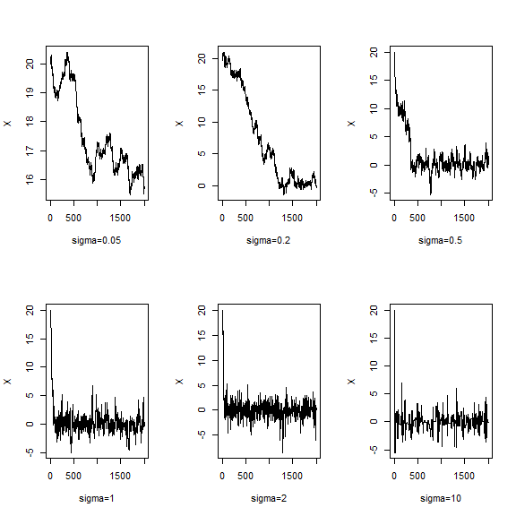

```r
par(mfrow=c(2,3))
plot(rw1$x,type='l',xlab='sigma=0.05',ylab='X')
plot(rw2$x,type='l',xlab='sigma=0.2',ylab='X')
plot(rw3$x,type='l',xlab='sigma=0.5',ylab='X')
plot(rw4$x,type='l',xlab='sigma=1',ylab='X')
plot(rw5$x,type='l',xlab='sigma=2',ylab='X')
plot(rw6$x,type='l',xlab='sigma=10',ylab='X')
```

## Gelman-Rubin method for Exercise 9.4

### Problem

For Exercise 9.4, use the Gelman-Rubin method to monitor convergence of the chain, and run the chain until it converges approximately to the target distribution according to $\hat{R}<1.2$

### Solution

```r
Gelman.Rubin <- function(psi) {
# psi[i,j] is the statistic psi(X[i,1:j])
# for chain in i-th row of X
psi <- as.matrix(psi)
n <- ncol(psi)
k <- nrow(psi)
psi.means <- rowMeans(psi) #row means
B <- n * var(psi.means) #between variance est.
psi.w <- apply(psi, 1, "var") #within variances
W <- mean(psi.w) #within est.
v.hat <- W*(n-1)/n + (B/n) #upper variance est.
r.hat <- v.hat / W #G-R statistic
return(r.hat)
}

k <- 4    # four chains
x0 <- c(-10,-5,5,10)    # overdispersed initial values
N <- 10000    # length of chains
b <- 200    # burn-in length

par(mfrow=c(2,2))

X <- matrix(nrow=k,ncol=N)
for (i in 1:k)
  X[i,] <- rw.Metro.Laplace(0.2,x0[i],N)$x
psi <- t(apply(X, 1, cumsum))
for (i in 1:nrow(psi))
psi[i,] <- psi[i,] / (1:ncol(psi))
rhat <- rep(0, N)
for (j in (1000+1):N)
rhat[j] <- Gelman.Rubin(psi[,1:j])
plot(rhat[(1000+1):N], type="l", xlab="sigma=0.2", ylab="R_hat")
abline(h=1.2, lty=2)

X <- matrix(nrow=k,ncol=N)
for (i in 1:k)
  X[i,] <- rw.Metro.Laplace(1,x0[i],N)$x
psi <- t(apply(X, 1, cumsum))
for (i in 1:nrow(psi))
psi[i,] <- psi[i,] / (1:ncol(psi))
rhat <- rep(0, N)
for (j in (500+1):N)
rhat[j] <- Gelman.Rubin(psi[,1:j])
x2 <- min(which(rhat>0 & rhat<1.2))
plot(rhat[(500+1):N], type="l", xlab="sigma=1", ylab="R_hat")
abline(h=1.2, lty=2)

X <- matrix(nrow=k,ncol=N)
for (i in 1:k)
  X[i,] <- rw.Metro.Laplace(4,x0[i],N)$x
psi <- t(apply(X, 1, cumsum))
for (i in 1:nrow(psi))
psi[i,] <- psi[i,] / (1:ncol(psi))
rhat <- rep(0, N)
for (j in (b+1):N)
rhat[j] <- Gelman.Rubin(psi[,1:j])
x3 <- min(which(rhat>0 & rhat<1.2))
plot(rhat[(b+1):N], type="l", xlab="sigma=4", ylab="R_hat")
abline(h=1.2, lty=2)

X <- matrix(nrow=k,ncol=N)
for (i in 1:k)
  X[i,] <- rw.Metro.Laplace(16,x0[i],N)$x
psi <- t(apply(X, 1, cumsum))
for (i in 1:nrow(psi))
psi[i,] <- psi[i,] / (1:ncol(psi))
rhat <- rep(0, N)
for (j in (b+1):N)
rhat[j] <- Gelman.Rubin(psi[,1:j])
x4 <- min(which(rhat>0 & rhat<1.2))
plot(rhat[(b+1):N], type="l", xlab="sigma=16", ylab="R_hat")
abline(h=1.2, lty=2)

c(x2,x3,x4)
```

[output not shown]

## Exercise 11.4

### Problem

Find the intersection points $A(k)$ in $(0,\sqrt{k})$ of the curves
$$S_{k-1}(a)=P\left(t(k-1)>\sqrt{\frac{a^{2}(k-1)}{k-a^{2}}}\right)$$
and
$$S_{k}(a)=P\left(t(k)>\sqrt{\frac{a^{2} k}{k+1-a^{2}}}\right)$$
for $k=4:25,100,500,1000$, where t(k) is a Student t random variable with k degrees of freedom.

### Solution

```r
S <- function(k,a) {
  tmp <- sqrt(a^2*k/(k+1-a^2))
  pt(tmp, df=k)
}
k_store <- 4:25

result <- numeric(length(k_store)+3)
count <- 0

for (k in k_store) {
  count <- count+1
  target <- function(a) {
    S(k,a)-S(k-1,a)
  }
  out <- uniroot(target,  lower = 0.001, upper = sqrt(k)-0.1)
  result[count] <- out$root
}

target_100 <- function(a) {
    S(100,a)-S(99,a)
  }
out <- uniroot(target_100,  lower = 0.001, upper = sqrt(100)-4)    # To avoid meeting upper bound
result[23] <- out$root

target_500 <- function(a) {
    S(500,a)-S(499,a)
  }
out <- uniroot(target_500,  lower = 0.001, upper = sqrt(500)-20)    # To avoid meeting upper bound
result[24] <- out$root

target_1000 <- function(a) {
    S(1000,a)-S(999,a)
  }
out <- uniroot(target_1000,  lower = 0.001, upper = sqrt(1000)-25)    # To avoid meeting upper bound
result[25] <- out$root

cbind(k=c(k_store,100,500,1000),result)
```

```
##          k   result
##  [1,]    4 1.492096
##  [2,]    5 1.533581
##  [3,]    6 1.562759
##  [4,]    7 1.584417
##  [5,]    8 1.601163
##  [6,]    9 1.614516
##  [7,]   10 1.625383
##  [8,]   11 1.634409
##  [9,]   12 1.642025
## [10,]   13 1.648539
## [11,]   14 1.654176
## [12,]   15 1.659097
## [13,]   16 1.663437
## [14,]   17 1.667311
## [15,]   18 1.670731
## [16,]   19 1.673832
## [17,]   20 1.676639
## [18,]   21 1.679130
## [19,]   22 1.681457
## [20,]   23 1.683585
## [21,]   24 1.685542
## [22,]   25 1.687346
## [23,]  100 1.720600
## [24,]  500 1.729718
## [25,] 1000 1.730897
```

# Homework 9 (2020-11-24)

## A-B-O blood type problem

### Problem

Let the three alleles be A, B and O.

(Table omitted)

Observed data: A-type: $n_{A \cdot }=444$

B-type: $n_{B \cdot }=132$

O-type: $n_{OO}=361$

AB-type: $n_{AB}=63$

1. Use EM algorithm to solve MLE of $p$ and $q$. (consider missing data $n_{AA}$ and $n_{BB}$)
2. Record the values of $p$ and $q$ that maximize the conditional likelihood in each EM steps, calculate the corresponding log-maximum likelihood values (for observed data), are they increasing?

### Solution

Observed data likelihood:
$$L(p,q|n_{A\cdot},n_{B\cdot},n_{OO},n_{AB})=(p^2+2p(1-p-q))^{n_{A\cdot}}(q^2+2q(1-p-q))^{n_{B\cdot}}((1-p-q)^2)^{n_{OO}}(2pq)^{n_{AB}}$$

Complete data likelihood:
$$L(p,q|n_{AA},n_{BB},n_{OO},n_{AO},n_{BO},n_{AB})=(p^2)^{n_{AA}}(q^2)^{n_{BB}}((1-p-q)^2)^{n_{OO}}(2p(1-p-q))^{n_{AO}}(2q(1-p-q))^{n_{BO}}(2pq)^{n_{AB}}$$
$$L(p,q|n_{A\cdot},n_{B\cdot},n_{OO},n_{AB},n_{AA},n_{BB})=(p^2)^{n_{AA}}(q^2)^{n_{BB}}((1-p-q)^2)^{n_{OO}}(2p(1-p-q))^{n_{A\cdot}-n_{AA}}(2q(1-p-q))^{n_{B\cdot}-n_{BB}}(2pq)^{n_{AB}}$$

$$l(p,q|n_{A\cdot},n_{B\cdot},n_{OO},n_{AB},n_{AA},n_{BB}) = 2n_{OO}\log (1-p-q) + n_{AB} \log (pq) + n_{A\cdot}\log (p(1-p-q)) + n_{B\cdot}\log (q(1-p-q)) + n_{AA}\log (p/(1-p-q)) + n_{BB}\log (q/(1-p-q))$$
E-Step:
$$\begin{aligned}
&E_{\hat{p}_0,\hat{q}_0}[l(p,q|n_{A\cdot},n_{B\cdot},n_{OO},n_{AB},n_{AA},n_{BB})|n_{A\cdot},n_{B\cdot},n_{OO},n_{AB}]\\
&= 2n_{OO}\log (1-p-q) + n_{AB} \log (pq) + n_{A\cdot}\log (p(1-p-q)) + n_{B\cdot}\log (q(1-p-q))\\
&+ \frac{\hat{p}_0^2}{\hat{p}_0^2+2 \hat{p}_0(1-\hat{p}_0-\hat{q}_0)} n_{A\cdot}\log (p/(1-p-q)) + \frac{\hat{q}_0^2}{\hat{q}_0^2+2 \hat{q}_0(1-\hat{p}_0-\hat{q}_0)} n_{B\cdot}\log (q/(1-p-q))
\end{aligned}$$

M-Step:
$$\hat{p}_1=\frac{1}{2n}(2n_{A\cdot}\frac{\hat{p}_0^2}{\hat{p}_0^2+2 \hat{p}_0(1-\hat{p}_0-\hat{q}_0)}+n_{A\cdot}\frac{2 \hat{p}_0(1-\hat{p}_0-\hat{q}_0)}{\hat{p}_0^2+2 \hat{p}_0(1-\hat{p}_0-\hat{q}_0)}+n_{AB})$$
$$\hat{q}_1=\frac{1}{2n}(2n_{B\cdot}\frac{\hat{q}_0^2}{\hat{q}_0^2+2 \hat{q}_0(1-\hat{p}_0-\hat{q}_0)}+n_{B\cdot}\frac{2 \hat{q}_0(1-\hat{p}_0-\hat{q}_0)}{\hat{q}_0^2+2 \hat{p}_0(1-\hat{p}_0-\hat{q}_0)}+n_{AB})$$

```r
na <- 444
nb <- 132
noo <- 361
nab <- 63
n <- na+nb+noo+nab
p <- rep(0,10)
q <- rep(0,10)
condlike <- rep(0,10)
p[1] <- 0.5    # Initial value
q[1] <- 0.2    # Initial value
for (i in 1:9) {
  x1 <- p[i]^2/(p[i]^2+2*p[i]*(1-p[i]-q[i]))
  x2 <- q[i]^2/(q[i]^2+2*q[i]*(1-p[i]-q[i]))
  r <- 1-p[i]-q[i]
  condlike[i] <- 2*noo*log(r) + nab*log(p[i]*q[i]) + na*log(p[i]*r) + nb*log(q[i]*r) + x1*na*log(p[i]/r) + x2*nb*log(q[i]/r)
  p[i+1] <- (2*na*x1+na*(1-x1)+nab)/(2*n)
  q[i+1] <- (2*nb*x2+nb*(1-x2)+nab)/(2*n)
  r <- 1-p[i+1]-q[i+1]
}
r <- 1-p[10]-q[10]
condlike[10] <- 2*noo*log(r) + nab*log(p[10]*q[10]) + na*log(p[10]*r) + nb*log(q[10]*r) + x1*na*log(p[10]/r) + x2*nb*log(q[10]/r)

data.frame(p=p,q=q,conditional_log_likelihood=condlike)
```

```
##            p         q conditional_log_likelihood
## 1  0.5000000 0.2000000                  -2138.309
## 2  0.3544091 0.1140000                  -1834.233
## 3  0.3090018 0.1038915                  -1806.187
## 4  0.2997498 0.1028649                  -1802.872
## 5  0.2980256 0.1027319                  -1802.342
## 6  0.2977106 0.1027107                  -1802.248
## 7  0.2976534 0.1027071                  -1802.231
## 8  0.2976430 0.1027064                  -1802.228
## 9  0.2976411 0.1027063                  -1802.227
## 10 0.2976407 0.1027063                  -1802.227
```

From the result, we could find that the corresponding log-maximum likelihood values are increasing. The parameters converge after 9 iterations. The estimated $\hat{p}=0.2976407,~~\hat{q}=0.1027063$

## Exercises 3 (P204)

### Problem

Use both for loops and lapply() to fit linear models to the mtcars using the formulas stored in this list:

formulas <- list( mpg ~ disp, mpg ~ I(1 / disp), mpg ~ disp + wt, mpg ~ I(1 / disp) + wt )

### Solution

```r
attach(mtcars)
formulas <- list(
mpg ~ disp,
mpg ~ I(1 / disp),
mpg ~ disp + wt,
mpg ~ I(1 / disp) + wt
)

# loops
models_1 <- list()
for (i in 1:4)
  models_1[[i]] <- lm(formulas[[i]])
models_1
```

```
## [[1]]
##
## Call:
## lm(formula = formulas[[i]])
##
## Coefficients:
## (Intercept)         disp
##    29.59985     -0.04122
##
##
## [[2]]
##
## Call:
## lm(formula = formulas[[i]])
##
## Coefficients:
## (Intercept)    I(1/disp)
##       10.75      1557.67
##
##
## [[3]]
##
## Call:
## lm(formula = formulas[[i]])
##
## Coefficients:
## (Intercept)         disp           wt
##    34.96055     -0.01772     -3.35083
##
##
## [[4]]
##
## Call:
## lm(formula = formulas[[i]])
##
## Coefficients:
## (Intercept)    I(1/disp)           wt
##      19.024     1142.560       -1.798
```

```r
# lapply
models_2 <- list()
models_2 <- lapply(formulas, function(x) lm(x))
models_2
```

```
## [[1]]
##
## Call:
## lm(formula = x)
##
## Coefficients:
## (Intercept)         disp
##    29.59985     -0.04122
##
##
## [[2]]
##
## Call:
## lm(formula = x)
##
## Coefficients:
## (Intercept)    I(1/disp)
##       10.75      1557.67
##
##
## [[3]]
##
## Call:
## lm(formula = x)
##
## Coefficients:
## (Intercept)         disp           wt
##    34.96055     -0.01772     -3.35083
##
##
## [[4]]
##
## Call:
## lm(formula = x)
##
## Coefficients:
## (Intercept)    I(1/disp)           wt
##      19.024     1142.560       -1.798
```

## Exercises 3 (P213)

### Problem

The following code simulates the performance of a t-test for non-normal data. Use sapply() and an anonymous function to extract the p-value from every trial.

trials <- replicate( 100, t.test(rpois(10, 10), rpois(7, 10)), simplify = FALSE )

Extra challenge: get rid of the anonymous function by using [[ directly.

### Solution

```r
trials <- replicate(
100,
t.test(rpois(10, 10), rpois(7, 10)),
simplify = FALSE
)
sapply(trials, (function(x) x[['p.value']]))
```

```
##   [1] 0.07117554 0.62033641 0.43748589 0.79442851 0.07907674 0.79088495
##   [7] 0.12719411 0.05146878 0.73032721 0.29291370 0.37742331 0.79010396
##  [13] 0.83351492 0.80564489 0.74909759 0.38298284 0.90803990 0.10057939
##  [19] 0.10512960 0.97662420 0.09753150 0.10444059 0.23323142 0.57173463
##  [25] 0.87038383 0.73093172 0.83319434 0.73855863 0.55232805 0.01079548
##  [31] 0.88098028 0.26390299 0.47814278 0.76330439 0.64797225 0.74717936
##  [37] 0.24666759 0.01497308 0.90092990 0.62201682 0.61395015 0.58523070
##  [43] 0.18923033 0.25443558 0.96491075 0.03147520 0.09974982 0.78751682
##  [49] 0.09219353 0.50199861 0.62743535 0.77595120 0.38097159 0.54327290
##  [55] 0.72761540 0.72639827 0.64843487 0.82103195 0.06166524 0.84951608
##  [61] 0.67496219 0.21199482 0.87805322 0.01974717 0.54971668 0.48082379
##  [67] 0.01040104 0.83292427 0.65126790 0.96844390 0.25942469 0.29464802
##  [73] 0.58925510 0.53538065 0.30254633 0.27326479 0.97036931 0.37979510
##  [79] 0.34254824 0.95329304 0.05540916 0.24316689 0.29454995 0.59402599
##  [85] 0.18958669 0.33655461 0.68243512 0.10385217 0.79709998 0.17275542
##  [91] 0.31582674 0.81653685 0.38327468 0.56334057 0.59348975 0.31475327
##  [97] 0.23459041 0.44549778 0.96031601 0.48277756
```

```r
sapply(trials, '[[', 'p.value')    # extra challenge
```

```
##   [1] 0.07117554 0.62033641 0.43748589 0.79442851 0.07907674 0.79088495
##   [7] 0.12719411 0.05146878 0.73032721 0.29291370 0.37742331 0.79010396
##  [13] 0.83351492 0.80564489 0.74909759 0.38298284 0.90803990 0.10057939
##  [19] 0.10512960 0.97662420 0.09753150 0.10444059 0.23323142 0.57173463
##  [25] 0.87038383 0.73093172 0.83319434 0.73855863 0.55232805 0.01079548
##  [31] 0.88098028 0.26390299 0.47814278 0.76330439 0.64797225 0.74717936
##  [37] 0.24666759 0.01497308 0.90092990 0.62201682 0.61395015 0.58523070
##  [43] 0.18923033 0.25443558 0.96491075 0.03147520 0.09974982 0.78751682
##  [49] 0.09219353 0.50199861 0.62743535 0.77595120 0.38097159 0.54327290
##  [55] 0.72761540 0.72639827 0.64843487 0.82103195 0.06166524 0.84951608
##  [61] 0.67496219 0.21199482 0.87805322 0.01974717 0.54971668 0.48082379
##  [67] 0.01040104 0.83292427 0.65126790 0.96844390 0.25942469 0.29464802
##  [73] 0.58925510 0.53538065 0.30254633 0.27326479 0.97036931 0.37979510
##  [79] 0.34254824 0.95329304 0.05540916 0.24316689 0.29454995 0.59402599
##  [85] 0.18958669 0.33655461 0.68243512 0.10385217 0.79709998 0.17275542
##  [91] 0.31582674 0.81653685 0.38327468 0.56334057 0.59348975 0.31475327
##  [97] 0.23459041 0.44549778 0.96031601 0.48277756
```

## Exercises 6 (P214)

### Problem

Implement a combination of Map() and vapply() to create an lapply() variant that iterates in parallel over all of its inputs and stores its outputs in a vector (or a matrix). What arguments should the function take?

### Solution

```r
lapply_1 <- function(X, FUN, FUN.VALUE) {
  return(Map(function(x) vapply(x,FUN,FUN.VALUE),X))
}
list_comb <- list(cars,mtcars,faithful)
lapply_1(list_comb, mean, numeric(1))
```

```
## [[1]]
## speed  dist
## 15.40 42.98
##
## [[2]]
##        mpg        cyl       disp         hp       drat         wt       qsec
##  20.090625   6.187500 230.721875 146.687500   3.596563   3.217250  17.848750
##         vs         am       gear       carb
##   0.437500   0.406250   3.687500   2.812500
##
## [[3]]
## eruptions   waiting
##  3.487783 70.897059
```

# Homework 10 (2020-12-01)

### Problem

1.Write an Rcpp function for Exercise 9.4.

2.Compare the corresponding generated random numbers with those by the R function you wrote before using the function “qqplot”.

3.Compare the computation time of the two functions with the function “microbenchmark”.

4.Comments your results.

## Solution

```r
# Rcpp function for Exercise 9.4 (rwC.cpp)

#include <Rcpp.h>
using namespace Rcpp;
// [[Rcpp::export]]
NumericVector rwC (double sigma, double x0, int N) {
    NumericVector u = runif(N);
    NumericVector x(N);
    x[0] = x0;
    for (int i=1; i <= N-1; i++) {
        NumericVector y = rnorm(1,x[i-1],sigma);
        if (u[i] <= exp(abs(x[i-1])-abs(y[0]))) {
            x[i] = y[0];
        }
        if (u[i] > exp(abs(x[i-1])-abs(y[0]))) {
            x[i] = x[i-1];
        }
    }
    return(x);
}
```

```r
# R function for Exercise 9.4 (my homework)

rw.Metro.Laplace <- function(sigma,x0,N) {
  u <- runif(N)
  x <- rep(0,N)
  x[1] <- x0
  k <- 0
  for (i in 2:N) {
    y <- rnorm(1, mean=x[i-1], sd=sigma)
    if (u[i] <= exp(abs(x[i-1])-abs(y)))
      x[i] <- y else {
        x[i] <- x[i-1]
        k <- k+1
      }
  }
  return(list(x=x,k=k))
}
```

```r
library(Rcpp)
sourceCpp("rwC.cpp")
```

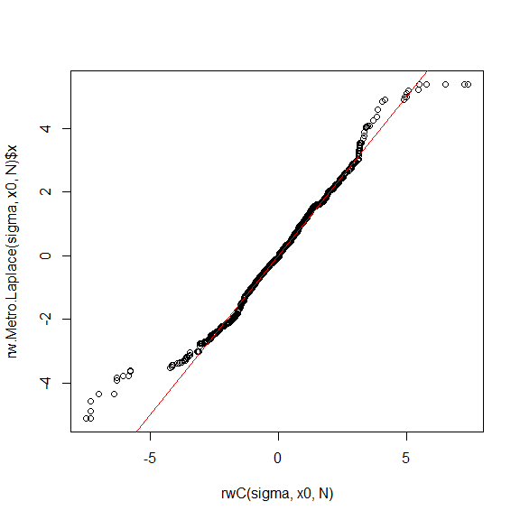

```r
sigma <- 2
x0 <- 5
N <- 2000
qqplot(rwC(sigma,x0,N), rw.Metro.Laplace(sigma,x0,N)$x)
abline(a=0,b=1,col='red')
```

The corresponding generated random numbers could be assumed same, because the Q-Q plot of these two data mostly scatters near the diagonal line.

```r
library(microbenchmark)
ts <- microbenchmark(rwC=rwC(sigma,x0,N), rwR=rw.Metro.Laplace(sigma,x0,N)$x)
summary(ts)[,c(1,3,5,6)]
```

```
##   expr      lq   median      uq
## 1  rwC   794.9   810.65   913.0
## 2  rwR 12122.9 13573.55 15704.9
```

It’s clear that Rcpp function takes much shorter time than R function. Thus, Rcpp can tremendously increase the efficiency.